CONTENT  
- Consistency of the OLS estimator  
- Asymptotic normality of the OLS estimators  
- LM Testing  
- Nonlinearity in the regression  
- Considerations When Using Logarithms  
- Models with Quadratics  
- Generalizing Considerations When Using Quadratics  
- Summary

Econometrics

Designed by Professor Sasha Shapoval

for New Uzbekistan University

Multiple Regression OLS Further Issues Dummy variables

Multiple Linear Regression: Further Issues

**This part of tutorial** provides a focused exploration of key topics in applied regression analysis, bridging both theoretical concepts and practical implementation. We begin by examining the **consistency** of the OLS estimator and the conditions under which it reliably converges to the true parameter values, followed by a discussion of the **asymptotic normality** of OLS estimators, which underpins inference in large samples.

Building on this foundation, we introduce **Lagrange Multiplier (LM) testing** as a method for evaluating the significance of subsets of regressors. The tutorial then addresses **nonlinearity in regression**, highlighting when and how transformations can improve model fit and interpretability. Specific attention is given to **logarithmic transformations** and **quadratic models**, including practical considerations for interpretation and the computation of turning points, culminating in a discussion on general strategies for incorporating quadratic terms effectively in empirical analyses.

This tutorial blends theoretical rigor with applied examples, equipping readers to handle a range of modeling challenges in real-world data.

🧮

# Consistency of the OLS estimator

🔹 Intuitive explanation of consistency

1. **Absence of bias**: Let $\hat b^j$ be the OLS estimator of some coefficient $b_j$ in a regression. For a sample of size $n$, $\hat b^j$ has a **probability distribution** representing the possible values it could take if we drew many random samples of the same size.

Under the usual OLS assumptions (MLR.1–MLR.4), $\hat b^j$ is **unbiased**, which means the mean of its distribution equals the true parameter:

$$ \mathbf{E}[\hat b^j] = b_j $$

2. **Consistency**: An estimator $\hat b^j$ is **consistent** if, as the sample size $n$ grows, its distribution becomes **tightly concentrated around the true parameter $b_j$**. Formally:

$$ \hat b^j \xrightarrow{p} b_j \quad \text{as } n \to \infty, \quad \text{$\xrightarrow{p}$ denotes convergence in probability} $$

Intuitively:

- With a small sample, $\hat b^j$ may vary a lot from one sample to another.
- As $n$ increases, the estimator becomes **more accurate** and fluctuates less.
- In the limit, as $n \to \infty$, the estimator **collapses to the true value** $b_j$:

$$ \text{Distribution of } \hat b^j \longrightarrow \text{a single point at } b_j $$

Consistency means that **if we can collect more and more data, our estimator can be made arbitrarily close to the true parameter**.

It is an **asymptotic property**, focusing on what happens as the sample size becomes very large, rather than exact properties in a finite sample.

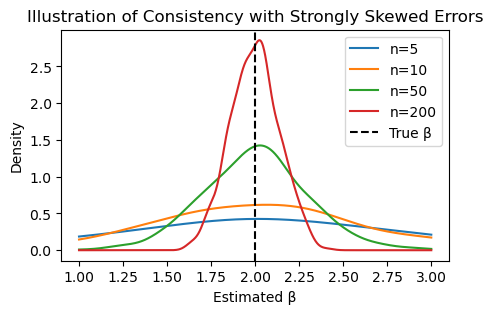

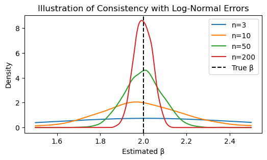

$\newcommand{\Exp}{\mathbf{E}}$ $\newcommand{\Var}{\mathbf{Var}}$ $\newcommand{\Cov}{\mathbf{Cov}}$

Proof - simple regression case - originates from the following equation

\begin{equation} \hat{\beta}_1 = \beta_1 + \frac{\sum_{i=1}^n (x_i - \bar{x})u_i}{\sum_{i=1}^n (x_i - \bar{x})^2} \label{e:regr:beta1} \end{equation}

Divide by $1/n$ both numerator and denominator:

$$ \hat{\beta}_1 = \beta_1 + \frac{n^{-1}\sum_{i=1}^n (x_i - \bar{x})u_i}{n^{-1}\sum_{i=1}^n (x_i - \bar{x})^2} $$

Then the sums converge to the covariance and variance in probability as $n \to \infty$:

$$ \hat{\beta}_1 = \beta_1 + \frac{\Cov(u, x)}{\Var(x)} = 0 \quad\text{as $\Cov(u, x) = 0$.} $$

**Question: As you know, the covariance is $$ \Cov(u, x) = \frac{1}{n} \sum_i (u_i - \bar{u}) (x_i - \bar{x}) $$ We do not have $\bar{u}$ above but refer to the expression as **covariance**. Why?**

$\bar{u} = 0$, according to assumptions

**Info**

Convergence in probability requires the existence of $\Var(u)$ and $\Var(x)$.

The condition $\Cov(u, x) = 0$ and $\Exp(u) = 0$ is weaker than $\Exp(u \,|\, x) = 0$

if the error is correlated with any of the independent variables, then OLS is biased and inconsistent $$ \hat{\beta}_1 - \beta_1 = \frac{\Cov(x_1, u)}{\Var(x_1)} $$

# Asymptotic normality of the OLS estimators

🔹 Theorem: Asymptotic normality

Under the following assumptions:

1. The data $\{(y_i, x_i)\}_{i=1}^n$ are i.i.d.
2. The model is correctly specified: $E[u_i \mid x_i] = 0$.
3. The regressors satisfy the full rank and moment conditions:  
   $E[x_i x_i']$ is positive definite and $E[\|x_i\|^4] < \infty$.
4. The errors satisfy $E[u_i^2 \mid x_i] < \infty$ (no requirement of normality).

Then:

$$ \sqrt{n}(\hat\beta - \beta) \;\xrightarrow{d}\; N\!\left(0,\; Q^{-1} \, \Omega \, Q^{-1} \right), $$

where

- $Q = E[x_i x_i']$
- $\Omega = E[u_i^2 x_i x_i']$

represent the population second moments.

🧩 **Special case: Homoskedastic errors**

If, in addition, $Var(u_i \mid x_i) = \sigma^2$ (homoskedasticity), then

$$ \sqrt{n}(\hat\beta - \beta) \; \xrightarrow{d}\; N\!\left(0,\; \sigma^2 Q^{-1} \right). $$

This theorem justifies **asymptotic confidence intervals** and **t-tests** in large samples.

We are going to use it in the way that $$ \frac{\hat{\beta}_j - \beta_j}{se(\hat{\beta}_j)} \quad\text{asymptotically normal: }\quad \mathbf{N} (0, 1) $$ where $se(\hat{\beta}_j)$ is the usual OLS standard error

**Question: What is the distribution of $$\frac{\hat{\beta}_j - \beta_j}{se(\hat{\beta}_j)}$$ with a *finite* sample under standard OLS assumptions?**

$t_{n-k-1}$, where $k$ is the number of independent variables

🔍 Asymptotic Behavior of the OLS Standard Error

- The estimated variance of the slope estimator is
  $$\operatorname{Var}(\hat\beta_j) = \frac{\hat{s}^2}{\text{SST}_j(1 - R_j^2)}.$$
- Components:
  - $\hat{s}^2 \xrightarrow{p} \sigma^2$ as $n \to \infty$.
  - $R_j^2$ converges to a constant in $(0,1)$.
  - The sample variance satisfies
    $$\text{SST}_j / n \xrightarrow{p} \operatorname{Var}(x_j),$$
    so $\text{SST}_j$ grows on the order of $n$.
- Implication:
  - Since $\hat{s}^2$ does not grow with $n$ and $\text{SST}_j \sim n$,
    $$\operatorname{Var}(\hat\beta_j) \sim\frac{1}{n},$$
    meaning the variance shrinks at rate $1/n$.
- Terminology:
  - When $u$ is not normal, the square root of the expression above is called the *asymptotic standard error*.
  - Corresponding t-statistics are *asymptotic t-statistics*.
  - In practice, we still call them “standard errors” and “t-statistics,” understanding that the justification may be asymptotic.
- From the rate result: $$se(\hat\beta_j) \approx \frac{c_j}{\sqrt{n}},$$
  where $c_j > 0$ does not depend on $n$.

# LM Testing

🔍 for Excluding $q$ Parameters from the multiple regression

- **Goal:** Test whether a set of $q$ parameters can be excluded from the model.
- **Null hypothesis:** the last $q$ coefficients are zeros: $H_0: \beta_{n} = \beta_{n-1} = \cdots = \beta_{n-q+1} = 0$
- **Procedure:**
  1. Estimate the **restricted model** (excluding the $q$ parameters)

  $$ y_i = \beta_0 + \beta_1 x_{i1} + \beta_2 x_{i2} + \cdots + \beta_{n-q} x_{i,n-q} + u_i, \quad i = 1, \ldots, n $$

  2. Obtain residuals $\hat{u}$.  
  3. Regress $\hat{u}$ on all regressors (restricted + excluded).  
  4. Compute  
  $LM = n R^2_{\hat{u}}$
- **Asymptotic distribution:**  
  $LM \to \chi^2_q$ (chi2 distribution with $q$ degree of freedom)
- **Decision rule:** Under the confidence level of $\alpha$, reject $H_0$ if  
  $LM > \chi^2_{1-\alpha, q}$

⚖️ Economic Model of Crime (the Wooldridge handbook)

We illustrate the LM test using a slight extension of the crime model from Example 3.5:

$$ narr86 = \beta_0 + \beta_1 pcnv + \beta_2 avgsen + \beta_3 tottime + \beta_4 ptime86 + \beta_5 qemp86 + u. $$

Definitions of variables:

- $narr86$: number of times a man was arrested
- $pcnv$: proportion of prior arrests leading to conviction
- $avgsen$: average sentence served from past convictions
- $tottime$: total time spent in prison before 1986 (age 18 onward)
- $ptime86$: months spent in prison in 1986
- $qemp86$: number of quarters in 1986 during which the man was legally employed

We use the LM statistic to test the null hypothesis that **avgsen** and **tottime** have no effect on  
$narr86$ once the other factors are controlled for.

```python
# Heiss & Brunner
import wooldridge as woo
import statsmodels.formula.api as smf
import scipy.stats as stats

# Load data
crime1 = woo.dataWoo('crime1')

# 1. Estimate restricted model
reg_r = smf.ols(formula='narr86 ~ pcnv + ptime86 + qemp86', data=crime1)
fit_r = reg_r.fit()
r2_r = fit_r.rsquared
print(f'r2_r: {r2_r}\n')

# 2. Regression of residuals from restricted model
crime1['utilde'] = fit_r.resid
reg_LM = smf.ols(
    formula='utilde ~ pcnv + ptime86 + qemp86 + avgsen + tottime',
    data=crime1
)
fit_LM = reg_LM.fit()
r2_LM = fit_LM.rsquared
print(f'r2_LM: {r2_LM}\n')

# 3. LM test statistic
LM = r2_LM * fit_LM.nobs
print(f'LM: {LM}\n')

# 4. Critical value (chi-squared, alpha = 10%)
cv = stats.chi2.ppf(1 - 0.10, 2)
print(f'cv: {cv}\n')

# 5. p-value
pval = 1 - stats.chi2.cdf(LM, 2)
print(f'pval: {pval}\n')

# 6. Compare with F-test
reg = smf.ols(
    formula='narr86 ~ pcnv + ptime86 + qemp86 + avgsen + tottime',
    data=crime1
)
results = reg.fit()
hypotheses = ['avgsen = 0', 'tottime = 0']
ftest = results.f_test(hypotheses)

fstat = ftest.statistic
fpval = ftest.pvalue

print('F-test:')
print(f'fstat: {fstat}\n')
print(f'fpval: {fpval}\n')
```

```
r2_r: 0.04132330770123083

r2_LM: 0.0014938456737876304

LM: 4.070729461071293

cv: 4.605170185988092

pval: 0.1306328280326915

F-test:
fstat: 2.0339215584351016

fpval: 0.13102048172760739
```

🔍 Exercise 6.C1

**(i) Level–Level Model** Estimate: $$ wage_i = \beta_0 + \beta_1 educ_i + \beta_2 exper_i + \beta_3 tenure_i + u_i. $$

- Obtain the OLS residuals $\hat{u}_i$.
- Plot a histogram of $\hat{u}_i$ to assess symmetry, outliers, and tail behavior.

**(ii) Log–Level Model** Estimate: $$ \log(wage_i) = \beta_0 + \beta_1 educ_i + \beta_2 exper_i + \beta_3 tenure_i + u_i. $$

- Obtain residuals from this regression.
- Plot a histogram of these residuals.

**(iii) Which model is closer to satisfying MLR.6 (normality of errors)?**

Residuals from the **log(wage)** regression typically look:

- more symmetric,
- less right-skewed,
- with fewer extreme outliers.

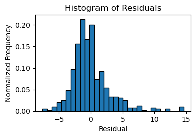

```python
import wooldridge as woo
import statsmodels.formula.api as smf
wage1 = woo.dataWoo('wage1')
reg = smf.ols(formula='wage ~ educ + exper + tenure', data=wage1)
results = reg.fit()

import matplotlib.pyplot as plt
import seaborn as sns

fig, ax = plt.subplots(1, 1, figsize=(4, 2.5))
#ax.scatter(fitted, residuals) #earlier, we used this; now, the historgram is required
ax.hist(results.resid, bins=30, edgecolor='black', density=True) #normalized frequency with density=True
ax.set_xlabel('Residual')
ax.set_ylabel('Normalized Frequency')
ax.set_title('Histogram of Residuals')
plt.show() #to visualize the plot; sometimes it is even without this line
```

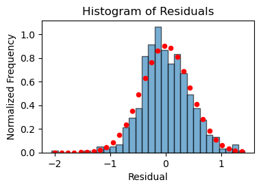

```python
import wooldridge as woo
import statsmodels.formula.api as smf
wage1 = woo.dataWoo('wage1')
reg = smf.ols(formula='lwage ~ educ + exper + tenure', data=wage1)
results = reg.fit()

import matplotlib.pyplot as plt
import seaborn as sns
import numpy as np
from scipy.stats import norm

fig, ax = plt.subplots(1, 1, figsize=(4, 2.5))
# Histogram
ax.hist(results.resid, bins=bin_edges, edgecolor='black', alpha=0.6, density=True)
# Generate x-values for normal density curve
res_mean = np.mean(results.resid)
res_std = np.std(results.resid)
# Compute histogram (density=True)
counts, bin_edges = np.histogram(results.resid, bins=30, density=True)
bin_centers = 0.5 * (bin_edges[:-1] + bin_edges[1:])
bin_widths = bin_edges[1:] - bin_edges[:-1]
# Mean and std of residuals
res_mean = np.mean(results.resid)
res_std = np.std(results.resid)
# Compute normal histogram heights using the SAME bin edges
prob_mass = norm.cdf(bin_edges[1:], loc=res_mean, scale=res_std) - norm.cdf(bin_edges[:-1],
                        loc=res_mean, scale=res_std)
normal_hist_heights = prob_mass / bin_widths
# Normal histogram points
ax.scatter(bin_centers, normal_hist_heights, color='red', s=20, label='Normal histogram points')

ax.set_xlabel('Residual')
ax.set_ylabel('Normalized Frequency')
ax.set_title('Histogram of Residuals')
plt.show() #to visualize the plot; sometimes it is even without this line
```

**Question: If you want to train your intuition regarding the proximity to normality, what would you do? If you want to test the hypothesis**

Draw a sample of the same size from the (visualized) normal distribution, plot its histogram, and look at the similarity with the red dots. You can make this experiment several times.

Run the Kolomogorov--Smirnoff test (but not chi2-test)

🔍 Exercise 6.C3, the Wooldridge handbook

Using the `BWGHT` data set, we want to compute the **Lagrange Multiplier (LM) statistic** to test whether `motheduc` and `fatheduc` are jointly significant.

**Steps:**

1. **Restricted model:**  
   Estimate the regression **excluding** `motheduc` and `fatheduc`:

   $$ bwght_i = \beta_0 + \beta_1 \, cigs_i + \beta_2 \, faminc_i + \beta_3 \, male_i + u_i $$

   Make sure to use **only observations for which all variables in the unrestricted model are available**.
2. **Obtain residuals** $\hat{u}_i$ from the restricted model.
3. **Auxiliary regression:**  
   Regress the residuals $\hat{u}_i$ on **all regressors from the unrestricted model**:

   $$ \hat{u}_i = \gamma_0 + \gamma_1 \, cigs_i + \gamma_2 \, faminc_i + \gamma_3 \, male_i + \gamma_4 \, motheduc_i + \gamma_5 \, fatheduc_i + v_i $$
4. **Compute LM statistic:**

   $$ LM = n \times R^2_{\text{auxiliary regression}} $$

   where $n$ is the number of observations used.
5. **Compare to critical value or compute p-value:**
   - Degrees of freedom = number of excluded variables = 2
   - Reject the null hypothesis if $LM > \chi^2_{0.10,2}$ at 10% significance.

```python
import wooldridge as woo
import statsmodels.formula.api as smf
from scipy.stats import chi2

# Load data
bwght = woo.dataWoo('bwght')

# Drop rows with missing values for the unrestricted model
vars_unrestricted = ['bwght', 'motheduc', 'fatheduc', 'cigs', 'faminc', 'male']
bwght_clean = bwght.dropna(subset=vars_unrestricted).copy()  # <-- copy ensures safe assignment

# Step 1: Restricted model (exclude motheduc and fatheduc)
formula_restricted = 'bwght ~ cigs + faminc + male'
reg_r = smf.ols(formula=formula_restricted, data=bwght_clean)
fit_r = reg_r.fit()

# Step 2: Obtain residuals
bwght_clean.loc[:, 'resid_r'] = fit_r.resid #fitted residuals are added into the table

# Step 3: Auxiliary regression of residuals on all regressors of unrestricted model
formula_aux = 'resid_r ~ cigs + faminc + male + motheduc + fatheduc'
reg_aux = smf.ols(formula=formula_aux, data=bwght_clean)
fit_aux = reg_aux.fit()

# Step 4: Compute LM statistic
R2_aux = fit_aux.rsquared
n_obs = fit_aux.nobs
LM = n_obs * R2_aux
print(f'LM statistic: {LM:.4f}')

# Step 5: Compare to chi-square with df = number of restrictions (here 2)
df = 2
cv_10 = chi2.ppf(0.90, df)  # 10% significance level
p_value = 1 - chi2.cdf(LM, df)

print(f'10% chi-square critical value: {cv_10:.4f}')
print(f'p-value: {p_value:.4f}')
```

```
LM statistic: 3.1102
10% chi-square critical value: 4.6052
p-value: 0.2112
```

# Nonlinearity in the regression

## Considerations When Using Logarithms

1. **Interpretation of coefficients**
   - Coefficients have **percentage change interpretations**.
   - The units of measurement do not affect coefficients in log form. For example, changing dollars to thousands of dollars does **not** affect the coefficient of a logged variable.
2. **Common usage**
   - Logs are often used for **dollar amounts** (always positive) and variables such as **population** with large variation.
   - They are used less often for variables measured in **years**, such as schooling, age, or experience.
   - Logs are used infrequently for variables already expressed as **percentages or proportions**, e.g., unemployment rate or test pass rate.
3. **Classical linear model assumptions**
   - Models with $\log(y)$ as the dependent variable often better satisfy assumptions of linearity, homoskedasticity, and normality.
4. **Reducing variation and outlier influence**
   - Taking logs can reduce the variation of a variable, making OLS estimates less sensitive to outliers.
   - Caution: if $y$ is a fraction close to zero, $\log(y)$ can have **much more variability** than $y$, and for $y \approx 0$, $\log(y)$ is a large negative number.
5. **Non-positive values**
   - If $y \le 0$, $\log(y)$ is undefined.
   - Sometimes $\log(1 + y)$ is used, but interpretation becomes difficult.
6. **Large changes**
   - For large changes in an explanatory variable, the log model gives a more accurate estimate of **percent change effects**.
7. **Prediction challenges**
   - Predicting $y$ from a model estimated for $\log(y)$ is harder but possible.

🧩 Example: Logarithmic Dependent Variable

Suppose the annual number of drunk-driving arrests is determined by:

$$ \log(\text{arrests}) = \beta_0 + \beta_1 \log(\text{pop}) + \beta_2 \text{age16_25} + \text{other factors} $$

where `age16_25` is the proportion of the population aged 16–25.

- **Interpretation of $\beta_2$ (ceteris paribus):**  
  It represents the **percentage change in arrests** when the proportion of people aged 16–25 increases by **one percentage point**.

## Models with Quadratics

Quadratic functions are frequently used in applied economics to capture **decreasing or increasing marginal effects**. For a review of quadratic functions, see Appendix A.

In the simplest case, $y$ depends on a single observed factor $x$, but in a **quadratic fashion**:

$$ y = \beta_0 + \beta_1 x + \beta_2 x^2 + u $$

For example, let $y = \text{wage}$ and $x = \text{exper}$. As discussed in Chapter 3, this model is **beyond simple regression**, but can be handled easily with **multiple regression**.

🧩 Interpretation of Coefficients

- $\beta_1$ **does not measure the change in $y$ with respect to $x$** directly, because it does not make sense to hold $x^2$ fixed while changing $x$.
- The estimated equation is:

$$ \hat{y} = \hat{\beta}_0 + \hat{\beta}_1 x + \hat{\beta}_2 x^2 \tag{6.10} $$

- The change in $\hat{y}$ for a small change in $x$ is approximated by:

$$ \Delta \hat{y} \approx (\hat{\beta}_1 + 2 \hat{\beta}_2 x) \Delta x, \quad \text{so} \quad \frac{\Delta \hat{y}}{\Delta x} \approx \hat{\beta}_1 + 2 \hat{\beta}_2 x \tag{6.11} $$

This shows that the **slope depends on the value of $x$**.

- If we plug in $x = 0$, $\hat{\beta}_1$ can be interpreted as the approximate slope going from $x = 0$ to $x = 1$.
- Beyond that, the term $2 \hat{\beta}_2 x$ must be accounted for.

**Key idea:**

- The slope of the relationship between $x$ and $y$ is **not constant**; it is:

$$ \hat{\beta}_1 + 2 \hat{\beta}_2 x $$

- This slope varies with $x$, reflecting **changing marginal effects**.

🧩 Positive $\hat{\beta}_1$, negative $\hat{\beta}_2$, and **turning point**

Example, using the `WAGE1` data, we obtain:

- Number of observations: $n = 526$
- $R^2 = 0.093$

Use:

The first year of experience is worth roughly 0.30 dollars per hour ($0.298$)

The second year of experience is worth less, approximately $0.298 - 2 \cdot 0.0061 \cdot 1 \approx 0.286 \text{ (28.6¢) }$

In going from **10 to 11 years** of experience: $0.298 - 2 \cdot 0.0061 \cdot 10 \approx 0.176 \text{ (17.6¢) }$

🧩 Quadratic Interpretation

- When the coefficient on $x$ is positive and the coefficient on $x^2$ is negative, the quadratic has a **parabolic shape**.
- There is always a **positive value of $x$** where the effect of $x$ on $y$ is zero.
  - **Before** this turning point: $x$ has a positive effect on $y$
  - **After** this turning point: $x$ has a negative effect on $y$

In practice, it can be important to calculate **where this turning point occurs**.

## Generalizing Considerations When Using Quadratics

1. **Flexible effects**
   - A quadratic function allows for **increasing or decreasing effects** of a variable.
2. **Turning point**
   - The turning point of a quadratic is easily calculated and should be checked to see if it makes sense.
3. **Sign of coefficients**
   - If the coefficients of $x$ and $x^2$ have **opposite signs**, the turning point is positive.
   - If the signs are the same, the turning point is negative.
4. **Practical importance**
   - A seemingly small coefficient on $x^2$ can have **practical significance** in changing slopes.
   - Use a **t-test** to check statistical significance and compute slopes at various values of $x$ to assess practical importance.
5. **Partial effects and centering**
   - In a model quadratic in $x$, the coefficient on $x$ measures the partial effect starting from $x = 0$ (see equation 6.11).
   - If zero is not meaningful, **center $x$** around a relevant value (e.g., the sample mean) before squaring.
   - This corresponds to computing the **average partial effect**. Example: Exercise 6.12.

# Summary

1. Consistency of the OLS estimator
2. Asymptotic normality of the OLS estimators
3. LM Testing
4. Nonlinearity in the regression: logarithms and quadratics

Previous: Multiple Linear Regression Next: Dummy variables

Course homepage  
Distributed under a Creative Commons Attribution-NonCommercial-ShareAlike 4.0 International (CC BY-NC-SA 4.0) license